# PBHL-B 275 Final Project

Nate Peters

5/13/2021

## Introduction

For the 2019-2020 college basketball season, the 3-point line was extended to 22 feet, 1.75 inches. Prior to the switch, the distance was 20 feet, 9 inches. I plan to assess whether there was a statistically significant decrease in 3-point shooting percentages after the extension or if percentages are not out of the ordinary. I plan to do this because it could suggest that players had a hard time adjusting to the new distance, and I am interested in knowing if the extension actually had any real, significant effects. While I am guessing that the 3-point shooting percentages were a little lower throughout college basketball, I don’t necessarily know if they were significantly lower, as players often shot from well beyond the 3-point line before the extension.

## Methods

To set up the problem, I had to come up with a null hypothesis (what we assume to be true and try to provide evidence against). In this problem, $H_0$, or the null hypothesis, is: there was no difference in average 3-point shooting percentage after the extension of the 3-point line ($\delta=0=\mu_1-\mu_2$).

I also had to come up with an alternative hypothesis (the hypothesis we want to provide evidence for). $H_a$, the alternative hypothesis, is: there was a decrease in average 3-point shooting percentage after the extension of the 3-point line ($\delta<0=\mu_1<\mu_2$).

Then, I used my original dataset to create two separate datasets, one with stats from the 2020 season and the other with stats from the four seasons before that.

```r
#filter to 2020 stats
Stats2020 <- MRegularSeasonDetailedResults %>%
  filter(Season == 2020)

#filter to the four seasons before 2020
StatsPastBefore2020 <- MRegularSeasonDetailedResults %>%
  filter(Season == 2019 | Season == 2018 | Season == 2017 | Season == 2016)
```

Next, I manipulated both datasets to get 3-point stats for each team. After manipulating, the datasets were broken down into two more datasets, one for 3-point stats in wins, and the other in losses. For example, the 2020 stats dataset was broken down into two datasets, one containing each team’s 3-point stats when it won, and one containing each team’s 3-point stats when it lost.

```r
#get 3-point stats in 2020, by team, only in wins
WTeam3pStats2020 <- Stats2020 %>%
  group_by(WTeamID) %>%
  summarize(Tot3PAInW = sum(WFGA3),
            Tot3PMInW = sum(WFGM3)) %>%
  rename(TeamID = WTeamID)

#get 3-point stats in 2020, by team, only in losses
LTeam3pStats2020 <- Stats2020 %>%
  group_by(LTeamID) %>%
  summarize(Tot3PAInL = sum(LFGA3),
            Tot3PMInL = sum(LFGM3)) %>%
  rename(TeamID = LTeamID)

#get 3-point stats in the four seasons before 2020, by team, only in wins
WTeam3pStatsBefore2020 <- StatsPastBefore2020 %>%
  group_by(WTeamID) %>%
  summarize(Tot3PAInW = sum(WFGA3),
            Tot3PMInW = sum(WFGM3)) %>%
  rename(TeamID = WTeamID)

#get 3-point stats in the four seasons before 2020, by team, only in losses
LTeam3pStatsBefore2020 <- StatsPastBefore2020 %>%
  group_by(LTeamID) %>%
  summarize(Tot3PAInL = sum(LFGA3),
            Tot3PMInL = sum(LFGM3)) %>%
  rename(TeamID = LTeamID)
```

Next, I did two joins, one for the 2020 stats and one for the four seasons before. I did the joins to put 3-point stats for both wins and losses all in one dataset together. So, for the 2020 season stats, instead of having one dataset with 3-point stats in wins and one in losses, there is now just one dataset that has all of that information for each team. I did a full join because if a team either had no wins or no losses, I did not want any of the data to not make it through. In this case it wasn’t a problem, but it could be if you worked with more seasons.

```r
#join wins and losses 3-point stats datasets for 2020 season
RegSeason3PStats2020Joined <- full_join(WTeam3pStats2020, LTeam3pStats2020, by = c("TeamID"))

#join wins and losses 3-point stats datasets for the four seasons before 2020
RegSeason3PStatsBefore2020Joined <- full_join(WTeam3pStatsBefore2020, LTeam3pStatsBefore2020, by = c("TeamID"))
```

Then, I manipulated my data one last time. I only cared about the 3-point shooting percentage for each team, so I created a new variable that calculated the team’s 3-point shooting percentage and only kept the team IDs and 3-point shooting percentages for each dataset (2020 season and the dataset containing the four seasons before it).

```r
#manipulate the 2020 season dataset created in the last step to make a new one containing just the team IDs and their overall 3-point shooting percentages
RegSeason3PStats2020 <- RegSeason3PStats2020Joined %>%
  mutate(FGM3 = Tot3PMInW + Tot3PMInL,
         FGA3 = Tot3PAInW + Tot3PAInL,
         Percent3PM = FGM3 / FGA3) %>%
  select(TeamID, Percent3PM)

#manipulate the dataset for the four seasons before 2020 created in the last step to make a new one containing just the team IDs and their overall 3-point shooting percentages over that span
RegSeason3PStatsBefore2020 <- RegSeason3PStatsBefore2020Joined %>%
  mutate(FGM3 = Tot3PMInW + Tot3PMInL,
         FGA3 = Tot3PAInW + Tot3PAInL,
         Percent3PM = FGM3 / FGA3) %>%
  select(TeamID, Percent3PM)
```

After that, I did bootstrapping, which would help me determine whether there was a significant decrease in average 3-point shooting percentages after the 3-point line was extended.

My first step in bootstrapping was to calculate the average 3-point percentage for the 2020 season and also the four seasons before.

```r
m1 <- RegSeason3PStats2020 %>% summarize(mean = mean(Percent3PM))

m2 <- RegSeason3PStatsBefore2020 %>% summarize(mean = mean(Percent3PM))
```

I then did the actual bootstrapping.

```r
###BOOTSTRAPPING
set.seed(char2seed("Nate"))

nBS <- 1000

BSDiff <- numeric(nBS)


for (i in 1:nBS)
{
  m1BS <- RegSeason3PStats2020 %>% sample_n(size = dim(RegSeason3PStats2020)[1], replace = T)
  m2BS <- RegSeason3PStatsBefore2020 %>% sample_n(size = dim(RegSeason3PStatsBefore2020)[1], replace = T)
  BSDiff[i] <- mean(m1BS$Percent3PM) - mean(m2BS$Percent3PM)
}
```

To make sure the sample size was large enough for the Central Limit Theorem to apply, I created a histogram with a density plot included to show that the sampling distribution of the difference in average 3-point shooting percentage resembles a Normal distribution. With that knowledge, I calculated $z$, and using $z$, I calculated a p-value.

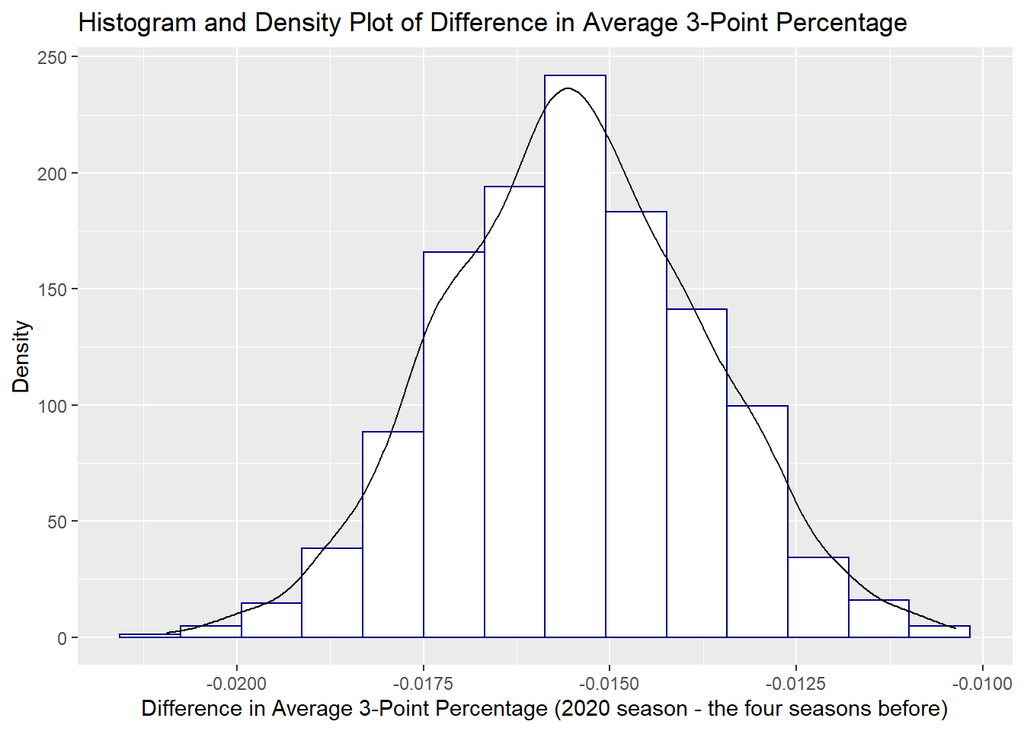

```r
BSDiffDF <- as.data.frame(BSDiff)


ggplot(data = BSDiffDF, aes(x=BSDiff))+
  geom_histogram(aes(y= ..density..), bins=14, fill="white", colour="darkblue") +
  geom_density()+
  xlab("Difference in Average 3-Point Percentage (2020 season - the four seasons before)")+
  ylab("Density")+
  ggtitle("Histogram and Density Plot of Difference in Average 3-Point Percentage")
```

```r
z <- (m1 - m2) / sd(BSDiff)


p <- pnorm(as.numeric(z), 0, 1)
```

In addition, I calculated a 95% confidence interval using the bootstrap principle to show a range of plausible values for the true difference in average 3-point shooting percentage after the extension.

```r
#find the 95% confidence interval for the difference in average 3-point percentages using the bootstrap principle

delta <- m1$mean - m2$mean
dstar <- BSDiff - delta

BSCI <- c(delta - quantile(dstar,0.975), delta - quantile(dstar, 0.025))
names(BSCI) <- c("2.5%", '97.5%')
```

## Results

After bootstrapping, I found $z$ = -8.8770211. We expected $z$ to have a N(0,1) distribution under $H_0$ because we assumed the difference in average 3-point shooting percentage was 0.

Using z, I found a p-value of 3.4337383^{-19}. Using a significance level of $\alpha=0.05$, there is sufficient statistical evidence to conclude that average 3-point shooting percentage was lower after the extension of the 3-point line.

Results from a 95% confidence interval using the bootstrap principle can be seen below.

```r
BSCI
```

```
##        2.5%       97.5%
## -0.01887328 -0.01208020
```

Therefore, it can be said that we are 95% confident that the true difference in average 3-point shooting percentage after the extension is between -0.0188733 and -0.0120802. In addition to the p-value that was found, the confidence interval also shows evidence that there was a decrease in average 3-point shooting percentage after the 3-point line extension.